# Python Basics II

Introduction to Pandas

[figure not shown]

In today's data-driven world, the ability to handle and make sense of vast amounts of information has become crucial. In 2021, more than 2.5 quintillion bytes of data were generated every day. As you can imagine, going through such enormous datasets to extract insights is not a task that can be accomplished with simple spreadsheet tools alone.

Enter the Python programming language, with Pandas at the forefront. Imagine you have a massive spreadsheet, filled with rows and columns of information. Each column represents a feature, and each row is a distinct data point. Often, these datasets are stored in structured formats like `.csv` or `.xlsx`. Now, suppose you want to ask questions like, 'Which regions had the highest instances of flu last year?' or 'How has the average weight of a particular demographic changed over the past decade?' However, your spreadsheet is too unwieldy, and merely opening it doesn't yield insights.

Pandas plays a pivotal role in countless data science and machine learning projects, thanks to its intricate yet user-friendly features. In the realm of machine learning (ML), where we train machines to make decisions based on data, having clean, well-structured, and thoroughly analyzed datasets is vital. Pandas equips us with the tools needed to prepare and analyze data before feeding it into ML algorithms.

Panda is not just a tool but a bridge between your stored data and the insights you're seeking. It provides a means to import these structured files into Python, offering an interactive platform for querying, modifying, and visualizing the data. Pandas, short for **Python Data Analysis Library**, provides powerful data structures to help analysts and data scientists work seamlessly with structured data. It is particularly efficient for manipulating and analyzing tabular datasets, like the ones commonly seen in public health studies.

Pandas acts like a magical magnifying glass for your data. With its core structures, **Series** and **DataFrame**, you can navigate even the most complex datasets effortlessly. Whether you're tracking trends, analyzing patterns, or simply organizing data, Pandas streamlines the process.

Here's a glimpse of what it can help you achieve:

- Calculating averages across diverse groups.
- Zooming in on specific data points based on defined criteria.
- Combining data from various sources to create a comprehensive overview.
- Crafting intuitive visual charts that highlight patterns and outliers.

For those seeking to unlock the full potential of their tabular data and transform numbers into compelling narratives, Pandas is the Python library of choice. For more in-depth details and resources, you can visit the official [Pandas](https://pandas.pydata.org/) website.

**What is a Programming Library?** In programming, a *library* refers to a set of pre-written code components that you can use to perform common tasks. Think of it like a toolbox, where each tool serves a specific function to help you accomplish something without starting from scratch. Python, which is an open-source language, offers a wide range of such libraries. *Open-source* means that the software's source code is freely available to the public. This not only promotes transparency but also encourages community-driven development and innovation.

Understanding the Dataset

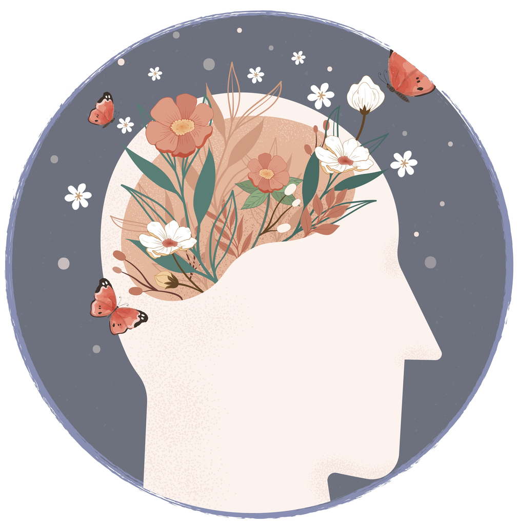

To begin our Pandas tutorial, the first step is loading your dataset into the environment. Pandas provides functions to read from various file formats, and today, we will focus on a common format: CSV (Comma-Separated Values). The dataset for this tutorial pertains to mental health, comprising simulated data representing different individuals and their mental health metrics. This dataset essentially provides a glimpse into various individuals and includes various metrics related to their mental health. For each person, we have information like age, gender, stress and anxiety levels, a general assessment of their mental well-being, and a suggestion for counseling hours. The objectives can vary, ranging from predicting an individual's mental well-being based on different factors to forecasting the recommended counseling hours.

**Key Features of the Dataset:**

As we explore Pandas, we will use this dataset to learn how to efficiently handle, manipulate, and derive insights from data. Through practical exercises, you will gain a hands-on understanding of how to work with data effectively to extract valuable information.

When working in environments like **Google Colab**, which operates in a cloud-based setting, we need to first upload our dataset to the environment before reading it. Let's dive in and see how this can be done:

**Step 1**: Upload the CSV file to Google Colab.

```
from google.colab import files
uploaded = files.upload()
```

Executing the code above will prompt you to select and upload a file. Choose the `mental_health_data.csv` file for this tutorial.

**Step 2**: Read the uploaded CSV file using Pandas.

```
import pandas as pd
import io

# Read the dataset into a Pandas DataFrame
df = pd.read_csv(io.BytesIO(uploaded['mental_health_data.csv']))

# Display the first few rows of the dataset to ensure it's loaded correctly
df.head()
```

The `df.head()` function presents the first five rows of our dataset, providing a quick way to check its content. With these steps, our data is now loaded into a Pandas DataFrame and is ready for us to explore!

> **Note:** If you are not using Google Colab, but a local Python environment, you can directly read the CSV using the line `df = pd.read_csv('mental_health_data.csv')` without needing the upload step.

```python
#Use this if you are running the code on Colab

from google.colab import files
import pandas as pd
import io

uploaded = files.upload()

# Read the dataset into a Pandas DataFrame
df = pd.read_csv(io.BytesIO(uploaded['mental_health_data.csv']))

# Display the first few rows of the dataset to ensure it's loaded correctly
df.head()
```

```python
#Use this when your CSV file is on your local machine, and it's in the same directory as your code.
import pandas as pd

df = pd.read_csv('mental_health_data.csv')
df.head()
```

|  | Age | Sex | Stress_Score | Anxiety_Level | Mental_Wellbeing | Counseling_Hours |
| --- | --- | --- | --- | --- | --- | --- |
| 0 | 53 | Male | 22.862516 | 73.806912 | Moderate | 4.833471 |
| 1 | 43 | Male | 90.870131 | 80.619588 | Moderate | 8.574486 |
| 2 | 29 | Male | 0.112011 | 84.373733 | Moderate | 4.224287 |
| 3 | 57 | Female | 55.618174 | 25.397487 | Moderate | 4.050783 |
| 4 | 22 | Male | 75.663580 | 3.111560 | Good | 3.938757 |

As observed, the variable `df` is a `pd.DataFrame` object, a core structure in `Pandas` designed to store tabular data. Our dataset encompasses 1000 rows (individual data samples) and 6 columns, painting a comprehensive picture of each data point.

Understanding the Dimensions of the Dataset–To begin, it is often useful to get a sense of the dataset's size in terms of its rows and columns. The following code will output the number of rows and columns in the form `(rows, columns)`.

```python
# Getting the shape of the dataframe
print(df.shape)
```

```
(1000, 6)
```

Viewing Column Names–A quick overview of the columns provides a sense of the data fields available.

```python
# List the columns of the dataframe
print(df.columns)
```

```
Index(['Age', 'Sex', 'Stress_Score', 'Anxiety_Level', 'Mental_Wellbeing',
       'Counseling_Hours'],
      dtype='object')
```

Adding a New Column–For the sake of demonstration, let's add a new column called `Mood`, which will randomly categorize individuals as `'Happy'`, `'Neutral'`, or `'Sad'`.

```python
import numpy as np
df['Mood'] = np.random.choice(['Happy', 'Neutral', 'Sad'], len(df))
df
```

|  | Age | Sex | Stress_Score | Anxiety_Level | Mental_Wellbeing | Counseling_Hours | Mood |
| --- | --- | --- | --- | --- | --- | --- | --- |
| 0 | 53 | Male | 22.862516 | 73.806912 | Moderate | 4.833471 | Sad |
| 1 | 43 | Male | 90.870131 | 80.619588 | Moderate | 8.574486 | Sad |
| 2 | 29 | Male | 0.112011 | 84.373733 | Moderate | 4.224287 | Neutral |
| 3 | 57 | Female | 55.618174 | 25.397487 | Moderate | 4.050783 | Happy |
| 4 | 22 | Male | 75.663580 | 3.111560 | Good | 3.938757 | Happy |
| ... | ... | ... | ... | ... | ... | ... | ... |
| 995 | 40 | Male | 73.967130 | 41.938961 | Moderate | 5.795305 | Neutral |
| 996 | 48 | Female | 19.126042 | 50.008012 | Good | 3.456703 | Happy |
| 997 | 59 | Female | 61.377742 | 78.509771 | Moderate | 6.994376 | Happy |
| 998 | 20 | Female | 43.550545 | 59.884540 | Moderate | 5.171754 | Happy |
| 999 | 51 | Male | 57.724973 | 20.109873 | Good | 3.891742 | Sad |

1000 rows × 7 columns

Dropping a Column–After some analysis, you might realize that a column is not necessary or is redundant. Let's remove the `Mood` column we just added.

```python
df.drop('Mood', axis=1, inplace=True)
df
```

|  | Age | Sex | Stress_Score | Anxiety_Level | Mental_Wellbeing | Counseling_Hours |
| --- | --- | --- | --- | --- | --- | --- |
| 0 | 53 | Male | 22.862516 | 73.806912 | Moderate | 4.833471 |
| 1 | 43 | Male | 90.870131 | 80.619588 | Moderate | 8.574486 |
| 2 | 29 | Male | 0.112011 | 84.373733 | Moderate | 4.224287 |
| 3 | 57 | Female | 55.618174 | 25.397487 | Moderate | 4.050783 |
| 4 | 22 | Male | 75.663580 | 3.111560 | Good | 3.938757 |
| ... | ... | ... | ... | ... | ... | ... |
| 995 | 40 | Male | 73.967130 | 41.938961 | Moderate | 5.795305 |
| 996 | 48 | Female | 19.126042 | 50.008012 | Good | 3.456703 |
| 997 | 59 | Female | 61.377742 | 78.509771 | Moderate | 6.994376 |
| 998 | 20 | Female | 43.550545 | 59.884540 | Moderate | 5.171754 |
| 999 | 51 | Male | 57.724973 | 20.109873 | Good | 3.891742 |

1000 rows × 6 columns

Accessing a Single Column–To focus on a single attribute or to perform operations on that, you might want to extract a specific column.

```python
# Access the 'Age' column
ages = df['Age']
print(ages.head())  # Displaying first 5 entries
```

```
0    53
1    43
2    29
3    57
4    22
Name: Age, dtype: int64
```

Accessing Multiple Columns–Often, you might want to analyze the relationship between multiple attributes. Extracting multiple columns is straightforward.

```python
# Access both 'Age' and 'Sex' columns
subset = df[['Age', 'Sex']]
print(subset.head())  # Displaying first 5 entries
```

```
   Age     Sex
0   53    Male
1   43    Male
2   29    Male
3   57  Female
4   22    Male
```

Descriptive Statistics–It is pivotal to gain insights into the statistical properties of the dataset. The `describe()` method provides count, mean, standard deviation, min, and max, along with the 25th, 50th, and 75th percentiles for numeric columns.

```python
# Display summary statistics
print(df.describe())
```

```
               Age  Stress_Score  Anxiety_Level  Counseling_Hours
count  1000.000000   1000.000000    1000.000000       1000.000000
mean     39.830000     49.451497      50.792275          5.012189
std      14.346809     28.437526      29.021376          2.045555
min      15.000000      0.033251       0.018840          0.169388
25%      28.000000     23.696697      25.370510          3.616581
50%      40.000000     49.988957      52.578441          5.021820
75%      51.000000     74.261698      76.200737          6.452764
max      64.000000     99.707816      99.971380          9.916983
```

Checking for Missing Values–Datasets often come with missing or null values. Identifying and dealing with them is crucial. In the presence of missing values, conventional methods involve addressing them through techniques such as *removal* or *imputation*.

```python
# Check for missing values in each column
print(df.isnull().sum())
```

```
Age                 0
Sex                 0
Stress_Score        0
Anxiety_Level       0
Mental_Wellbeing    0
Counseling_Hours    0
dtype: int64
```

Handling Categorical Features–In the context of Data Science, we frequently encounter two main types of features: **Numerical** and **Categorical**.

- **Numerical Features** are those that can take on a range of numeric values. For example, in our dataset, `Age` and `Counseling_Hours` are numerical features as they can be expressed as real numbers.
- **Categorical Features**, on the other hand, can only assume a limited set of distinct values. In our dataset, `Sex` is an example of a categorical feature, representing either `Male` or `Female`.

However, most machine learning algorithms require numerical input and output variables. Thus, we need to convert categorical data into a format that can be utilized by machine learning algorithms to enhance prediction accuracy.

- **Label Encoding:** One approach involves converting each value in a column into a number. For example, `Male` could be represented as `1`, and `Female` as `0`. However, this method has a drawback: the numeric values may erroneously imply a hierarchical or ordinal relationship.
- **One-Hot Encoding:** This method is often more suitable for categorical data without a natural order. With one-hot encoding, we create a new binary feature for each category in a feature, indicating the presence (1) or absence (0) of that category. For instance, if our dataset has a `Color` feature with values 'Red', 'Blue', and 'Green', one-hot encoding would produce three new columns: `Is_Red`, `Is_Blue`, and `Is_Green`, each with binary values.

The choice of encoding technique largely depends on the nature of the categorical data at hand. If there is an inherent order (ordinal data), label encoding might be appropriate. Otherwise, especially when avoiding unintended order assumptions, one-hot encoding is often preferred. However, caution should be exercised with one-hot encoding, particularly for features with numerous categories, as *it can significantly increase the dataset's dimensionality*.

**Applying Label Encoding to the 'Sex' Feature:** In our dataset, since `Sex` is binary (Male/Female), label encoding can be safely employed. The `map()` function is typically used to map values of a **Series** from one domain to another. It is commonly used for mapping categorical strings to numerical values. We can also use the `replace()` funciton. This function is more general and versatile than `map()`. It is used to replace specified values with others, and it can operate on both `DataFrames` and `Series`. While map() is strict and will map all values even if some were not specified (turning them into NaN), replace() only modifies the values specified, leaving others unchanged. While `map()` operates rigorously and assigns a mapping to all values, including those not explicitly specified (converting them to `NaN`), `replace()` selectively alters only the specified values, leaving the others unaffected.

```python
# Using the map() function to transform the 'Sex' column
df['Sex'] = df['Sex'].map({'Male': 0, 'Female': 1})

# Display the first few rows to see the transformation
print(df.head())
```

```
   Age  Sex  Stress_Score  Anxiety_Level Mental_Wellbeing  Counseling_Hours
0   53    0     22.862516      73.806912         Moderate          4.833471
1   43    0     90.870131      80.619588         Moderate          8.574486
2   29    0      0.112011      84.373733         Moderate          4.224287
3   57    1     55.618174      25.397487         Moderate          4.050783
4   22    0     75.663580       3.111560             Good          3.938757
```

```python
#Or you could run this instead of the above snippet.
# Using the replace() function to transform the 'Sex' column
df['Sex'] = df['Sex'].replace({'Male': 0, 'Female': 1})

# Display the first few rows to see the transformation
print(df.head())
```

```
   Age  Sex  Stress_Score  Anxiety_Level Mental_Wellbeing  Counseling_Hours
0   53    0     22.862516      73.806912         Moderate          4.833471
1   43    0     90.870131      80.619588         Moderate          8.574486
2   29    0      0.112011      84.373733         Moderate          4.224287
3   57    1     55.618174      25.397487         Moderate          4.050783
4   22    0     75.663580       3.111560             Good          3.938757
```

Visualizing the Distribution of Data Using Histograms

Before starting with the visualization, ensure you have both matplotlib and seaborn installed:

```
!pip install matplotlib seaborn
```

From the histogram, we can derive insights such as the concentration of users in certain age brackets and the range of ages present in our dataset.

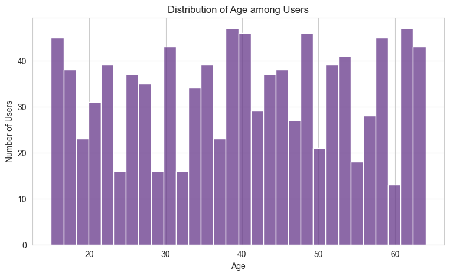

```python
# Import necessary libraries
import matplotlib.pyplot as plt
import seaborn as sns

# Set the style for seaborn
sns.set_style('whitegrid')

# Create a histogram for the 'Age' feature
plt.figure(figsize=(9, 5))
sns.histplot(df['Age'], bins=30, kde=False, color='#66378a')
plt.title('Distribution of Age among Users')
plt.xlabel('Age')
plt.ylabel('Number of Users')
plt.show()
```

Interactive Visualization–In the ever-evolving landscape of data science, interactivity has the potential to enhance our comprehension of datasets significantly. Unlike static plots, interactive plots enable users to delve further into particular segments, zoom in on areas of interest, and receive instant feedback on data points. `Plotly` represents one of the trailblazers in this field, delivering the dynamic capabilities of interactive visualization directly to Python users.

```python
# Import necessary libraries
import plotly.express as px
import plotly.io as pio
pio.renderers.default='notebook'

# Create an interactive histogram for the 'Age' feature
fig = px.histogram(df, x='Age', nbins=30, title='Distribution of Age among Users', color_discrete_sequence=['#b59a36'])

# Customizing the layout and theme
fig.update_layout(template="simple_white")

# Show the plot
fig.show('notebook')
```

[interactive chart not shown]

You are welcome to explore the color and theme configurations to harmonize the visualization with your personal preferences or the desired aesthetics for your audience.

After understanding the distribution of our data with histograms, it is often beneficial to explore the specifics of data spread, central tendency, and potential outliers. One of the most effective visual tools for this purpose is the **box plot** (or whisker plot).

A box plot gives a five-number summary of a dataset:

- The minimum (smallest observation)
- The first quartile (Q1 or the 25th percentile)
- The median (Q2 or the 50th percentile)
- The third quartile (Q3 or the 75th percentile)
- The maximum (largest observation)

Any data point that falls below $Q1 - 1.5 \times \text{IQR}$ or above $Q3 + 1.5 \times \text{IQR}$ is considered an outlier, where IQR (Inter-Quartile Range) is $Q3 - Q1$.

Using `Plotly`, we have the capability not only to create interactive visualizations of these summaries but also to hover over the plot and obtain exact values, which proves particularly valuable for thorough data exploration.

```python
# Create an interactive box plot for the 'Age' feature
fig_box = px.box(df, x='Sex', y='Age', title='Box Plot of Age Grouped by Sex', color='Sex', color_discrete_sequence=['#0d7b94', '#82153d'])

# Customizing the layout and theme
fig_box.update_layout(template="plotly_white")

# Show the plot
fig_box.show()
```

[interactive chart not shown]

By using this box plot, you can get a clear understanding of the age distribution for each gender, identifying the central age, spread, and any potential outliers. As always, the interactivity of `Plotly` enhances the user experience, allowing for precise data inspection.

Exploring 'groupby' in Pandas with Interactive Visualization

In data analysis, we often find the need to group our data based on certain criteria to uncover patterns at various levels of detail. This is where the Pandas `groupby` method proves valuable. With `groupby`, we can group our data by one or more columns and subsequently apply aggregate functions like sum, mean, or count to each group, resulting in a summarized perspective of the data.

For instance, suppose we wish to determine the average age of individuals in our dataset grouped by their gender. In such a scenario, we employ the `groupby` method to group the data by the 'Sex' column and calculate the mean age for each group.

Now, let's visualize the outcome of a `groupby` operation on our dataset using an interactive donut chart created with Plotly.

```python
# Using groupby to calculate the average age by sex
avg_age_by_sex = df.groupby('Sex')['Age'].mean().reset_index()

# Create an interactive donut chart
fig_donut = px.pie(avg_age_by_sex, names='Sex', values='Age', title='Average Age by Sex', hole=0.5)

# Customizing the color and theme
fig_donut.update_traces(textinfo='percent+label', pull=[0, 0], marker=dict(colors=['#0d7b94', '#82153d']))
fig_donut.update_layout(template="plotly_white")

# Show the plot
fig_donut.show()
```

[interactive chart not shown]

This donut chart provides an interactive way to grasp the condensed information obtained from our `groupby` operation. By hovering over individual segments, you can obtain precise values and percentages, allowing for a more profound exploration of the dataset.

Indexing with '.iloc' and '.loc' in Pandas

When it comes to working with data in pandas, one of the fundamental tasks is selecting or accessing specific rows, columns, or cells within our DataFrame. To achieve this with flexibility and efficiency, pandas offers two primary methods: `.iloc` and `.loc`. Let's explore these techniques using our mental health dataset.

**1. Introduction to `.iloc`**: `.iloc` predominantly relies on integer-based indexing, meaning it uses integer values to pinpoint data within the DataFrame. Think of it as choosing data based on its position within rows and columns.

```python
# Select the first row
first_row = df.iloc[0]

# Select the first five rows
first_five_rows = df.iloc[0:5]

# Select the first five rows and first two columns
subset = df.iloc[0:5, 0:2]

print(first_row)
print(first_five_rows)
print(subset)
```

```
Age                        53
Sex                         0
Stress_Score        22.862516
Anxiety_Level       73.806912
Mental_Wellbeing     Moderate
Counseling_Hours     4.833471
Name: 0, dtype: object
   Age  Sex  Stress_Score  Anxiety_Level Mental_Wellbeing  Counseling_Hours
0   53    0     22.862516      73.806912         Moderate          4.833471
1   43    0     90.870131      80.619588         Moderate          8.574486
2   29    0      0.112011      84.373733         Moderate          4.224287
3   57    1     55.618174      25.397487         Moderate          4.050783
4   22    0     75.663580       3.111560             Good          3.938757
   Age  Sex
0   53    0
1   43    0
2   29    0
3   57    1
4   22    0
```

- `df.iloc[0]`: Picks the initial row of the DataFrame.
- `df.iloc[0:5]`: Retrieves rows starting from position 0 up to (but not including) position 5.
- `df.iloc[0:5, 0:2]`: The first part `0:5` pertains to row selection, while the second part `0:2` pertains to column selection. This results in a subset of the first five rows and the first two columns.

**2. Introduction to `.loc`**: In contrast to `.iloc` which employs positions, `.loc` operates based on labels, utilizing the names or labels of rows and columns for data selection. When the DataFrame employs a custom index, such as names or dates, `.loc` proves especially useful.

```python
# Setting 'Sex' as our index for demonstration
df_indexed = df.set_index('Sex')

# Select rows for 'Male'
males_data = df_indexed.loc[0]

# Select data for 'Male' and specific columns 'Age' and 'Stress Level'
subset_males = df_indexed.loc[0, ['Age', 'Stress_Score']]

print(males_data.head())
print(subset_males.head())
```

```
     Age  Stress_Score  Anxiety_Level Mental_Wellbeing  Counseling_Hours
Sex
0     53     22.862516      73.806912         Moderate          4.833471
0     43     90.870131      80.619588         Moderate          8.574486
0     29      0.112011      84.373733         Moderate          4.224287
0     22     75.663580       3.111560             Good          3.938757
0     33      8.409822      31.491959             Good          1.995089
     Age  Stress_Score
Sex
0     53     22.862516
0     43     90.870131
0     29      0.112011
0     22     75.663580
0     33      8.409822
```

before we go on, i want to mention one little thing here, data sets are almost never perfect, and they may have missing values in them that means we don't have the value of a feature for some of the samples, for example, someone could leave some survey questions blank or things like this. We have to deal with missing values somehow, maybe remove all the samples that have missing values in them or replace them with some default value or try to estimate them using other features. For now, we skip these and will discuss them in later lectures when we encounter such a problems.

**3. Tips and Considerations**:

- Always remember, `.iloc` is for **integer-based** location indexing, and `.loc` is for **label-based** indexing.
- If you are unsure about the datatype of the index, use `df.index` to check.
- While it is common to have an integer index, do not confuse this with the positions in `.iloc`. Even if you have a DataFrame with an integer index starting from 100, `df.iloc[0]` will still give you the first row, but `df.loc[0]` will result in an error.

```python
import plotly.express as px

# Using .iloc to select first 50 rows of 'Depression Score'
selected_data = df.iloc[:50]['Anxiety_Level']

fig = px.line(selected_data, title='Depression Score of First 50 Individuals', color_discrete_sequence=['#a60c59'])
fig.update_layout(template="simple_white")  # You can change the template here
fig.show()
```

[interactive chart not shown]

**Example–Visualizing Data based on Criteria using `.loc`**

```python
# Using .loc to select 'Age' for females
female_ages = df.loc[df['Sex'] == 1, 'Age']

fig = px.histogram(female_ages, title='Age Distribution for Females', color_discrete_sequence=["#c2af1d"])  # Setting color to blueviolet
fig.update_layout(template="plotly_dark")  # Using plotly_dark template
fig.show()
```

[interactive chart not shown]

All the materials and examples from this tutorial are accessible on [Google Colab](https://drive.google.com/file/d/1VC26eiJpNW6qcODM9fOlADNMASJCsQLl/view?usp=sharing). I encourage you to actively run, modify, and test the code to enhance your learning and adapt it to your unique queries and tasks.